# Practical Machine Learning Assignment

Mudit Sharma

August 24, 2017

## Loading the Dataset

```r
library(caret)
```

```r
library(rpart)
library(rpart.plot)
library(RColorBrewer)
suppressMessages(library(rattle))
suppressMessages(library(randomForest))


train_data=read.csv(file = "pml-training.csv", na.strings = c("NA","#DIV/0",""))

test_data =read.csv(file = "pml-testing.csv", na.strings = c("NA","#DIV/0",""))
```

## Cleaning the Data

In this section, we will remove all columns that contains NA and remove features that are not in the testing dataset. The features containing NA are the variance, mean and standard devition (SD) within each window for each feature. Since the testing dataset has no time-dependence, these values are useless and can be disregarded. We will also remove the first 7 features since they are related to the time-series or are not numeric.

```r
features <- names(test_data[,colSums(is.na(test_data)) == 0])[8:59]

# Only use features used in testing cases.
train_data <- train_data[,c(features,"classe")]
test_data <- test_data[,c(features,"problem_id")]

dim(train_data); dim(test_data)
```

```
## [1] 19622    53
```

```
## [1] 20 53
```

## Partitioning the Dataset

Following the recommendation in the course Practical Machine Learning, we will split our data into a training data set (60% of the total cases) and a testing data set (40% of the total cases; the latter should not be confused with the data in the pml-testing.csv file). This will allow us to estimate the out of sample error of our predictor.

```r
set.seed(29-08-17)

inTrain <- createDataPartition(train_data$classe, p=0.6, list=FALSE)
training <- train_data[inTrain,]
testing <- train_data[-inTrain,]

dim(training); dim(testing)
```

```
## [1] 11776    53
```

```
## [1] 7846   53
```

## Building the Decision Tree Model

Using Decision Tree, we shouldn’t expect the accuracy to be high. In fact, anything around 80% would be acceptable.

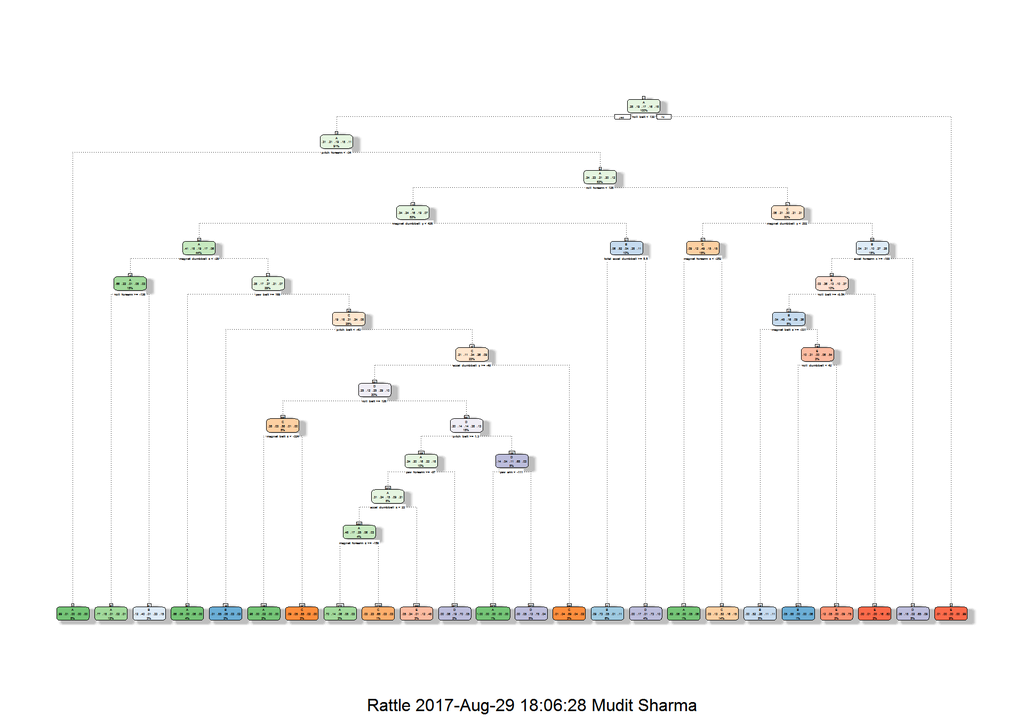

```r
modFitDT <- rpart(classe ~ ., data = training, method="class")
fancyRpartPlot(modFitDT)
```

## Predicting with the Decision Tree Model

```r
set.seed(29-08-17)

prediction <- predict(modFitDT, testing, type = "class")
confusionMatrix(prediction, testing$classe)
```

```
## Confusion Matrix and Statistics
##
##           Reference
## Prediction    A    B    C    D    E
##          A 2023  233   23   81   27
##          B   78  857  143  106  161
##          C   70  209 1110  175  166
##          D   22  116   92  855  110
##          E   39  103    0   69  978
##
## Overall Statistics
##
##                Accuracy : 0.7422
##                  95% CI : (0.7323, 0.7518)
##     No Information Rate : 0.2845
##     P-Value [Acc > NIR] : < 2.2e-16
##
##                   Kappa : 0.6732
##  Mcnemar's Test P-Value : < 2.2e-16
##
## Statistics by Class:
##
##                      Class: A Class: B Class: C Class: D Class: E
## Sensitivity            0.9064   0.5646   0.8114   0.6649   0.6782
## Specificity            0.9352   0.9229   0.9043   0.9482   0.9671
## Pos Pred Value         0.8475   0.6372   0.6416   0.7155   0.8225
## Neg Pred Value         0.9617   0.8983   0.9578   0.9352   0.9303
## Prevalence             0.2845   0.1935   0.1744   0.1639   0.1838
## Detection Rate         0.2578   0.1092   0.1415   0.1090   0.1246
## Detection Prevalence   0.3042   0.1714   0.2205   0.1523   0.1515
## Balanced Accuracy      0.9208   0.7437   0.8578   0.8065   0.8226
```

## Building the Random Forest Model

Using random forest, the out of sample error should be small. The error will be estimated using the 40% testing sample. We should expect an error estimate of < 3%.

```r
set.seed(29-08-17)
modFitRF <- randomForest(classe ~ ., data = training, ntree = 1000)
```

## Predicting with the Random Forest Model

```r
prediction <- predict(modFitRF, testing, type = "class")
confusionMatrix(prediction, testing$classe)
```

```
## Confusion Matrix and Statistics
##
##           Reference
## Prediction    A    B    C    D    E
##          A 2231   11    0    0    0
##          B    1 1503   10    0    0
##          C    0    4 1356   17    4
##          D    0    0    2 1268    5
##          E    0    0    0    1 1433
##
## Overall Statistics
##
##                Accuracy : 0.993
##                  95% CI : (0.9909, 0.9947)
##     No Information Rate : 0.2845
##     P-Value [Acc > NIR] : < 2.2e-16
##
##                   Kappa : 0.9911
##  Mcnemar's Test P-Value : NA
##
## Statistics by Class:
##
##                      Class: A Class: B Class: C Class: D Class: E
## Sensitivity            0.9996   0.9901   0.9912   0.9860   0.9938
## Specificity            0.9980   0.9983   0.9961   0.9989   0.9998
## Pos Pred Value         0.9951   0.9927   0.9819   0.9945   0.9993
## Neg Pred Value         0.9998   0.9976   0.9981   0.9973   0.9986
## Prevalence             0.2845   0.1935   0.1744   0.1639   0.1838
## Detection Rate         0.2843   0.1916   0.1728   0.1616   0.1826
## Detection Prevalence   0.2858   0.1930   0.1760   0.1625   0.1828
## Balanced Accuracy      0.9988   0.9942   0.9937   0.9925   0.9968
```

## Predicting on the Testing Data (pml-testing.csv)

### Decision Tree Prediction

```r
predictionDT <- predict(modFitDT, test_data, type = "class")
predictionDT
```

```
##  1  2  3  4  5  6  7  8  9 10 11 12 13 14 15 16 17 18 19 20
##  C  A  B  A  A  C  D  A  A  A  C  B  C  A  E  E  A  B  B  B
## Levels: A B C D E
```

## Random Forest Prediction

```r
predictionRF <- predict(modFitRF, test_data, type = "class")
predictionRF
```

```
##  1  2  3  4  5  6  7  8  9 10 11 12 13 14 15 16 17 18 19 20
##  B  A  B  A  A  E  D  B  A  A  B  C  B  A  E  E  A  B  B  B
## Levels: A B C D E
```

## Conclusion

As can be seen from the confusion matrix the Random Forest model is very accurate, about 99%. Because of that we could expect nearly all of the submitted test cases to be correct. It turned out they were all correct.